# Sampling distributions

POLI 210 - Seminar 6

Brad LeVeck

2026-10-07

## Today’s questions

- How can simulated values reveal a density?
- How does a statistic vary across repeated samples?
- What do the LLN and CLT tell us about a sample mean?
- Why do squared deviations and estimated standard errors lead to new distributions?

**Reading:** PSD Chapter 5, Sections 5.1-5.5, emphasizing chi-squared and $t$. All numerical examples here are hypothetical.

## Simulation reminder

For an event $A$, estimate $P(A)$ by the fraction of simulated outcomes in $A$.

```r
set.seed(100701)
B <- 10000
supporters <- rbinom(B, size = 4, prob = .6)
mean(supporters >= 3)
proportions(table(factor(supporters, levels = 0:4)))
```

`mean()` turns logical values into an estimated probability. `factor(..., levels = ...)` keeps possible outcomes with zero observed counts.

## An estimated PMF

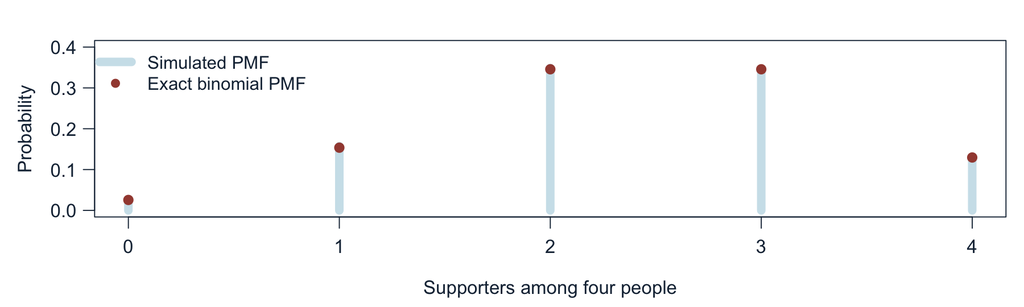

More replications improve our approximation to this **same** distribution. They do not change its true probabilities.

## Counts and areas in a histogram

Group $B=20$ draws into bins of width $2h=2$. For density heights, divide each count by $B(2h)=40$.

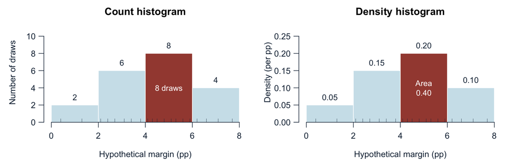

Highlighted bar: height $=8/40=0.20$, area $=2(0.20)=0.40=8/20$.

In R, `hist(draws, probability = TRUE)` makes the **total bar area one**.

## A local estimate of density

Last week, for a density continuous at $x$:

$$f(x)=\lim_{h\downarrow0}\frac{P(x-h\le X\le x+h)}{2h}.$$

For a bin centered at $x$, use its observed fraction and divide by its width:

$$\widehat f_h(x)=
\frac{\#\{b:x-h\le X_b\le x+h\}/B}{2h}.$$

This gives the **height** of the density bar. Multiplying by $2h$ recovers the fraction of draws in that bin.

## Narrower bins reveal detail and noise

The same 80 draws appear in every panel.

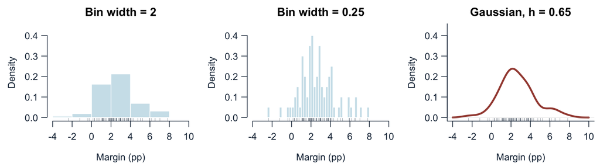

Narrow bins can be empty or spiky. Gaussian kernels use smooth weights instead of hard boundaries.

They still need a bandwidth: shrinking it too far also produces spikes.

## Kernel smoothing

Give each observed value a smooth bump centered at that value. Each bump contributes area $1/B$. Add the bumps.

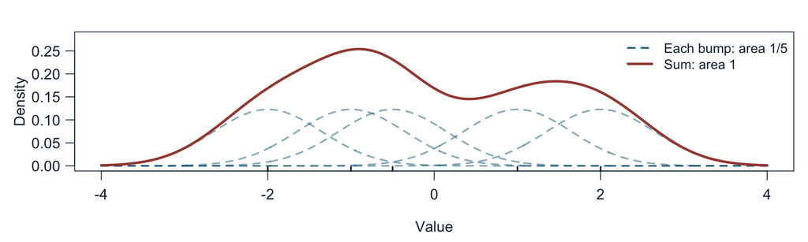

Nearby observations contribute most to the estimated height at $x$.

## A Gaussian kernel estimate

If $\phi$ is the standard Normal density and $h>0$ is the bandwidth,

$$\widehat f_h(x)=\frac{1}{B}\sum_{b=1}^{B}
\frac{1}{h}\phi\!\left(\frac{x-X_b}{h}\right).$$

- Each unweighted kernel is a Normal PDF with mean $X_b$ and SD $h$.
- Dividing by $B$ gives each observation an equal share of the total area.
- The resulting curve has area one and density units.

Gaussian **bumps** can form a non-Normal density, including several peaks.

## Bandwidth controls the amount of smoothing

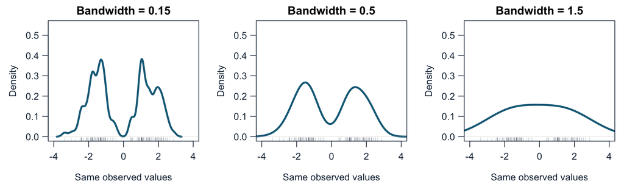

Small $h$ preserves fine detail and noise. Large $h$ can erase real features. Bandwidth is a smoothing choice, not the population standard deviation.

## What R’s density() does

```r
fit <- density(draws)          # Gaussian kernel by default
plot(fit)
fit$bw                        # chosen bandwidth
lines(density(draws, adjust = .5), col = "red")
```

R chooses a bandwidth and evaluates a kernel estimate on a grid. `adjust = .5` halves that bandwidth.

`fit$x` holds grid locations. `fit$y` holds estimated **density heights**. Use `mean(draws >= a & draws <= b)` for a simulated interval probability.

## A boundary caution

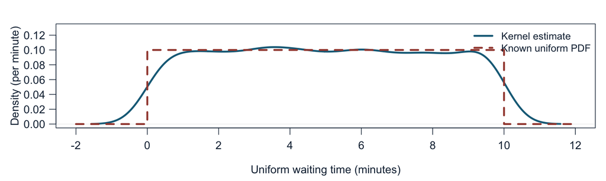

Gaussian kernels spread some area beyond known endpoints and smooth jumps. For bounded variables, inspect the support before interpreting the curve.

## A known parametric curve on the same axes

```r
draws <- rnorm(2000, mean = 3, sd = 5)
hist(draws, probability = TRUE)
lines(density(draws), col = "blue")
curve(dnorm(x, mean = 3, sd = 5), add = TRUE, col = "red")
```

The histogram and kernel estimate summarize the draws. The red curve uses the **known generating parameters**.

`curve()` creates a grid across the histogram’s x-axis range and supplies it as `x`, where `dnorm()` evaluates the density.

For real data, `mean(draws)` and `sd(draws)` give a simple fitted Normal comparison. Parameter estimation and model checking need more than a visual match. We will return to principled fitting methods later.

## A statistic is a random variable

Imagine repeatedly sampling people from a hypothetical debate audience. Population probabilities are 0.6 for A, 0.3 for B, and 0.1 for unsure.

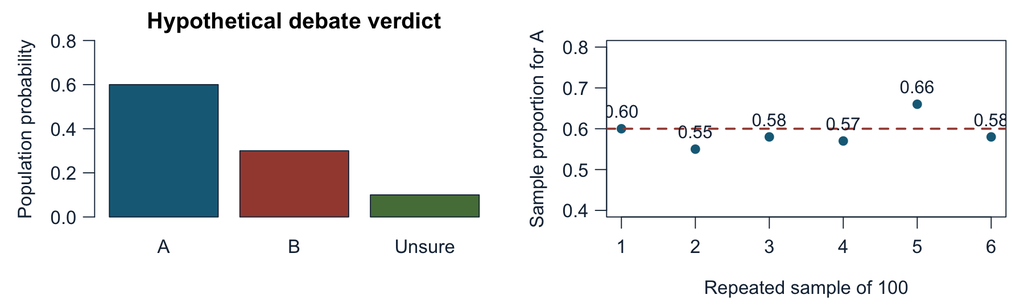

The population stays fixed. A new sample produces a new sample proportion.

## The sampling distribution

Let $X_i=1$ when person $i$ favors A and 0 otherwise.

$$\widehat p=\overline X=\frac{1}{n}\sum_{i=1}^{n}X_i.$$

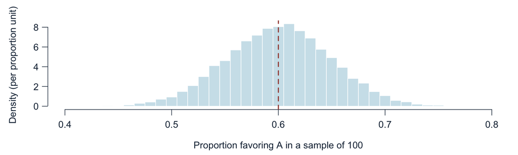

Each entry in this histogram summarizes an **entire sample of 100 people**.

## Sample size n and simulation replications B

```r
n <- 100                     # people in each sample
B <- 10000                   # repeated samples
sample_proportions <- replicate(B, {
  people <- rbinom(n, size = 1, prob = .6)
  mean(people)                # one statistic per sample
})
```

Changing $n$ changes the sampling distribution. Changing $B$ changes how accurately the simulation displays it.

## More samples versus larger samples

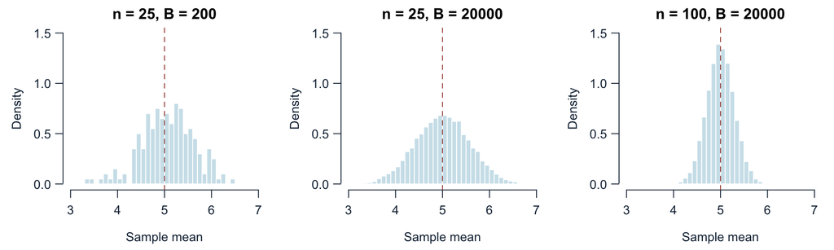

Here each observation is $\operatorname{Unif}(0,10)$. Compare the first two panels for $B$, then the last two for $n$.

## The iid model

$X_1,\ldots,X_n$ are **independent and identically distributed**:

- Each observation has the same distribution, with mean $\mu$ and variance $\sigma^2$.
- Learning one observation gives no information about another.
- Sampling with replacement from a fixed population produces this model.

Sampling without replacement creates dependence. When the sampling fraction is small, treating observations as independent may be a useful approximation.

Clustering, shared shocks, or selective participation need additional attention.

## The mean of the sample mean

$$\begin{aligned}
E[\overline X]
&=E\left[\frac{1}{n}\sum_{i=1}^{n}X_i\right]\\
&=\frac{1}{n}\sum_{i=1}^{n}E[X_i]
=\frac{n\mu}{n}=\mu.
\end{aligned}$$

This is an **exact** result at every sample size. Linearity of expectation does not require independence.

An individual sample mean will usually differ from $\mu$.

## The variance of the sample mean

Under independence and a common finite variance,

$$\begin{aligned}
\operatorname{Var}(\overline X)
&=\frac{1}{n^2}\operatorname{Var}\left(\sum_{i=1}^{n}X_i\right)\\
&=\frac{1}{n^2}\sum_{i=1}^{n}\operatorname{Var}(X_i)
=\frac{\sigma^2}{n}.
\end{aligned}$$

Thus $\operatorname{SD}(\overline X)=\sigma/\sqrt n$. This is the **standard error** of the sample mean under our model.

## Standard deviation and standard error

For an indicator with success probability $p=0.6$:

$$\sigma=\sqrt{0.6(0.4)}\approx0.490,
\qquad \operatorname{SE}(\widehat p)=\sqrt{\frac{0.6(0.4)}{n}}.$$

| Sample size | SD of an individual indicator | SE of sample proportion |
| --- | --- | --- |
| 25 | 0.490 | 0.098 |
| 100 | 0.490 | 0.049 |
| 400 | 0.490 | 0.0245 |

Quadrupling $n$ halves the SE. Increasing the number of simulated samples $B$ leaves this SE unchanged.

## The law of large numbers

For iid observations with a finite mean,

$$\overline X_n\xrightarrow{P}\mu.$$

For every fixed tolerance $\epsilon>0$,

$$P(|\overline X_n-\mu|>\epsilon)\longrightarrow0.$$

Large samples make substantial errors less likely. The claim does not require a Normal population or a Normal sampling distribution.

Simulation proportions also obey this logic: average the event indicators.

## Running averages

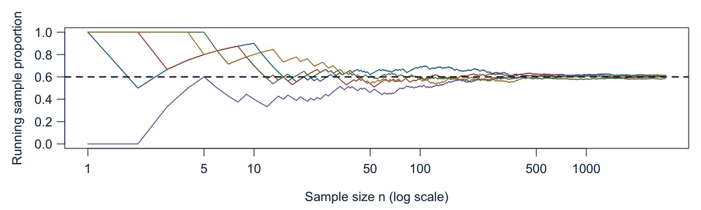

Five paths from the same Bernoulli model, $p=0.6$. An average can temporarily move farther from the truth as more data arrive.

## Center, concentration, and shape

| Result | What it tells us about the sample mean |
| --- | --- |
| $E[\overline X]=\mu$ | Center, exactly |
| $\operatorname{Var}(\overline X)=\sigma^2/n$ | Spread, exactly under iid finite variance |
| LLN | Concentration near $\mu$ as $n$ grows |
| CLT | Limiting shape after centering and scaling |

The LLN does not make individual observations less variable. A large sample also cannot repair a systematically unrepresentative design.

## Break

When we return: the shape of sampling distributions and the role of random denominators.

**Question to keep in mind:** What would change if we divided by an estimated standard error instead of the true one?

## Exact Normal sampling distributions

If $X_i$ are iid $\operatorname{Norm}(\mu,\sigma)$, then

$$\overline X\sim\operatorname{Norm}\left(\mu,\frac{\sigma}{\sqrt n}\right),$$

$$Z=\frac{\overline X-\mu}{\sigma/\sqrt n}
\sim\operatorname{Norm}(0,1)$$

**for every $n$**.

As in PSD, the second Normal parameter is the SD. With a non-Normal population, standardizing still gives mean 0 and variance 1, but those two moments do not establish a Normal shape.

## The central limit theorem

For iid observations with mean $\mu$ and $0<\sigma^2<\infty$,

$$\frac{\overline X_n-\mu}{\sigma/\sqrt n}
\xrightarrow{d}\operatorname{Norm}(0,1).$$

For sufficiently large $n$, this suggests

$$\overline X_n\ \approx\ \operatorname{Norm}\left(\mu,\frac{\sigma}{\sqrt n}\right).$$

The approximation concerns **sample means across repeated samples**. The observations themselves keep their original distribution.

## Uniform observations, standardized means

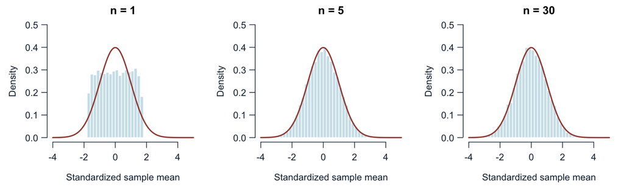

$X_i\sim\operatorname{Unif}(0,10)$, so $\mu=5$ and $\sigma=10/\sqrt{12}$. The red curve is the standard Normal PDF in every panel.

## A skewed population

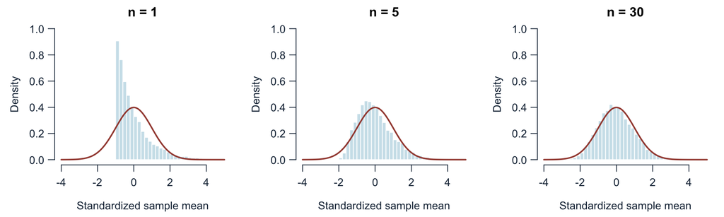

$X_i\sim\operatorname{Exp}(0.2)$, with $\mu=\sigma=5$. Skewness can require larger samples for an adequate Normal approximation.

## How close is the Normal approximation?

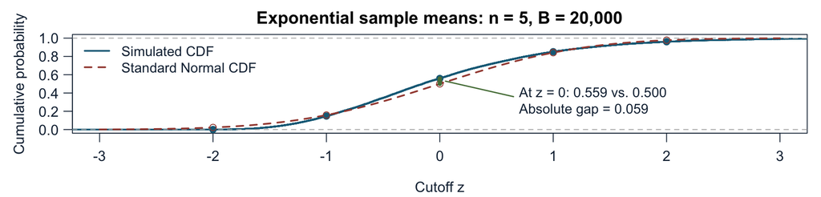

```r
mean(z_means <= 0)   # simulated P(Z_n <= 0)
pnorm(0)            # standard Normal P(Z <= 0)
```

**A4:** At $z=-2,-1,0,1,2$, require every absolute gap to be at most 0.02 (two percentage points).

Agreement at five checkpoints can coexist with differences elsewhere.

## No universal sample-size cutoff

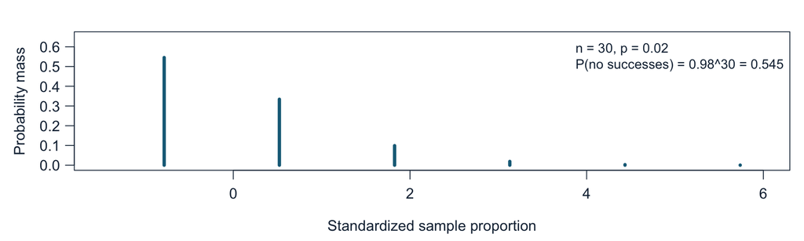

Thirty observations are not enough here to erase the rare-event skew. Approximation quality depends on the population and which probabilities matter.

## A Normal approximation to a poll

Suppose $p=0.6$, $n=400$, and sampling follows the iid indicator model.

$$P(0.55\le\widehat p\le0.65)
\approx P\left(-2.041\le Z\le2.041\right).$$

```r
se <- sqrt(.6 * .4 / 400)
c(normal = pnorm(.65, .6, se) - pnorm(.55, .6, se),
  exact = pbinom(260, 400, .6) - pbinom(219, 400, .6))
```

```
   normal     exact
0.9587732 0.9637269
```

The exact comparison includes counts 220 through 260. The uncorrected Normal calculation is approximate; a continuity correction would use boundaries 219.5 and 260.5 on the count scale.

## Squared standardized deviations

Suppose a discrepancy, divided by its known SD, follows $Z\sim\operatorname{Norm}(0,1)$.

$$Q=Z^2.$$

Squaring measures the **size** of a discrepancy in either direction:

| $Z$ | $-2$ | $-1$ | $0$ | $1$ | $2$ |
| --- | --- | --- | --- | --- | --- |
| $Z^2$ | 4 | 1 | 0 | 1 | 4 |

By definition, $Z^2\sim\chi^2_1$ exactly. If a standardized discrepancy is only approximately Normal, its square may be approximately chi-squared.

## The distribution of Z squared

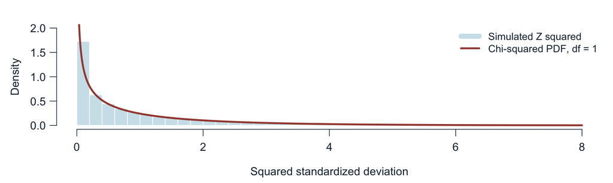

Values are nonnegative. Many are close to zero, with a long right tail. The PDF rises without bound at zero, but a single point still has probability zero.

## A total discrepancy

For independent standard Normal variables,

$$Q=Z_1^2+\cdots+Z_\nu^2\sim\chi^2_\nu.$$

Imagine independent, correctly standardized discrepancies from three polls. Values $2,-1,1.5$ give $Q=4+1+2.25=7.25$.

- Squaring prevents positive and negative discrepancies from cancelling.
- Standardizing puts discrepancies on comparable scales.
- The reference distribution describes ordinary variation under the assumed model.

Dependence or fitted constraints can change this reference distribution.

## Degrees of freedom and total variation

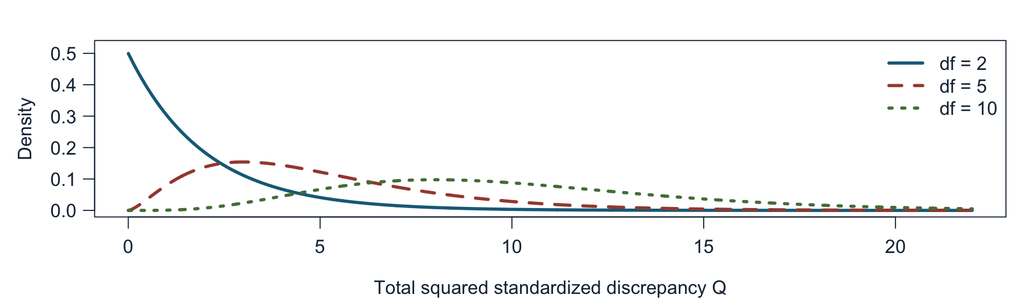

$$E[Q]=\nu,\qquad \operatorname{Var}(Q)=2\nu.$$

With more independent components, a larger total squared discrepancy is expected.

## Sample variance is also random

For a sample of $n$ observations,

$$S^2=\frac{1}{n-1}\sum_{i=1}^{n}(X_i-\overline X)^2.$$

Each new sample has its own $\overline X$ and $S^2$.

Under iid Normal sampling,

$$\frac{(n-1)S^2}{\sigma^2}\sim\chi^2_{n-1}.$$

This distribution tells us how a sample’s measured spread varies around the population’s spread. R computes $S^2$ with `var()` and $S$ with `sd()`.

## Why n minus 1?

Residuals around the sample mean satisfy

$$\sum_{i=1}^{n}(X_i-\overline X)=0.$$

Once $n-1$ residuals are known, the last is determined. Estimating the center uses one degree of freedom.

The residuals are **dependent**. Their squares are not $n$ independent chi-squared contributions.

For Normal samples, the total squared residual variation has $n-1$ independent components after a suitable change of coordinates. We use that result without deriving the coordinate transformation.

## A sampling distribution for variance

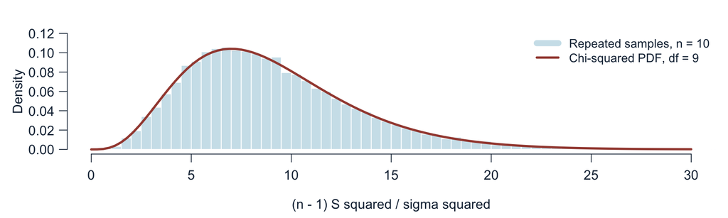

Here $n=10$ and the population SD is 4. Dividing by $\sigma^2$ removes the measurement scale.

## The t construction

Let $Z\sim\operatorname{Norm}(0,1)$ and $Q\sim\chi^2_\nu$ be independent.

$$T=\frac{Z}{D},\qquad D=\sqrt{Q/\nu},\qquad T\sim t_\nu.$$

$Q/\nu$ has mean 1 and variance $2/\nu$. Its square root is a random **relative SD**.

If $D<1$, division magnifies the numerator. If $D>1$, division shrinks it. Occasional small denominators create more extreme ratios.

## A random denominator

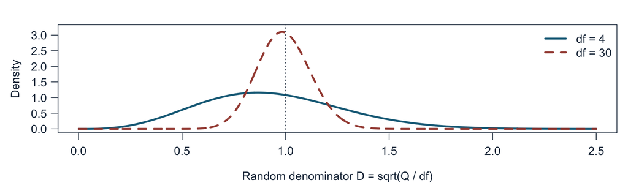

As $\nu$ grows, $Q/\nu$ concentrates near 1, and so does $D$. The square root’s mean is not exactly 1 at finite $\nu$.

## Heavier tails than a Normal

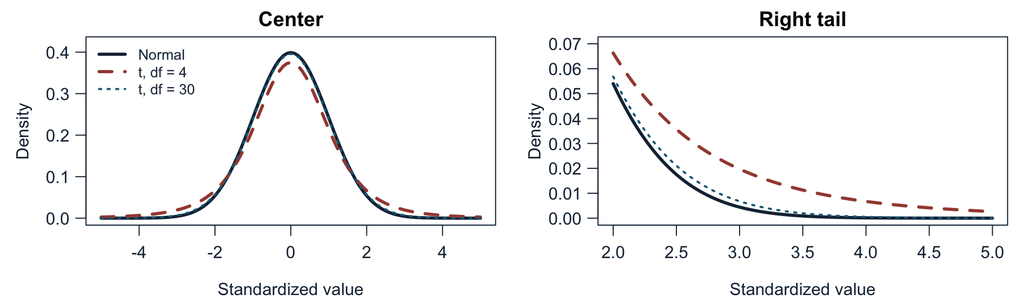

For $\nu>2$, $\operatorname{Var}(T)=\nu/(\nu-2)>1$. For $\nu\le2$, there is no finite variance. As $\nu$ grows, the $t$ distribution approaches standard Normal.

## Why this particular denominator?

For an iid Normal sample, define

$$Z=\frac{\overline X-\mu}{\sigma/\sqrt n},
\qquad Q=\frac{(n-1)S^2}{\sigma^2}.$$

Then $Z$ and $Q$ are independent and

$$\sqrt{\frac{Q}{n-1}}=\frac{S}{\sigma}.$$

The denominator represents the ratio of the **estimated** SD to the true SD. It follows from sampling variation in $S$, rather than an arbitrary decision to widen a Normal curve.

## Replacing the true standard error

$$\begin{aligned}
\frac{Z}{\sqrt{Q/(n-1)}}
&=\frac{\overline X-\mu}{\sigma/\sqrt n}
\frac{\sigma}{S}\\
&=\frac{\overline X-\mu}{S/\sqrt n}
\sim t_{n-1}.
\end{aligned}$$

$\sigma/\sqrt n$ is the true sampling SD. $S/\sqrt n$ is its estimate, and changes across samples.

This exact $t$ result requires iid **Normal** observations. For other populations, approximation quality needs separate consideration.

## A t statistic from each simulated sample

```r
n <- 10
B <- 10000
t_values <- replicate(B, {
  sample_x <- rnorm(n, mean = 12, sd = 4)
  (mean(sample_x) - 12) / (sd(sample_x) / sqrt(n))
})
hist(t_values, probability = TRUE)
curve(dt(x, df = n - 1), add = TRUE, col = "red")
```

Compute the sample mean and SD from the **same sample**. The known generating mean lets us study the statistic’s distribution.

## The simulated statistic and its reference curve

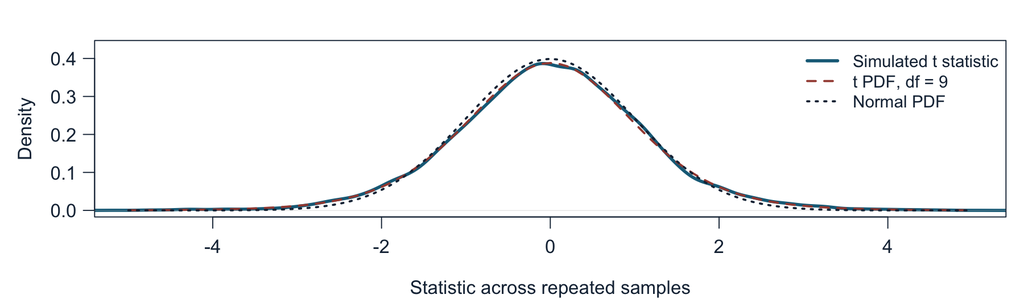

The $t$ reference anticipates uncertainty from estimating the denominator. We will use this relationship for inference later.

## Three distributions with distinct jobs

| Distribution | Construction | What varies? |
| --- | --- | --- |
| Standard Normal | $(\overline X-\mu)/(\sigma/\sqrt n)$ | Mean relative to a known SE |
| $\chi^2_{n-1}$ | $(n-1)S^2/\sigma^2$ | Estimated variance relative to true variance |
| $t_{n-1}$ | $(\overline X-\mu)/(S/\sqrt n)$ | Mean relative to an estimated SE |

These exact relationships hold for iid Normal samples. The CLT provides a broader, approximate route for standardized means.

## Retrieval questions

1. In a density histogram, what does a bar’s area estimate?
2. Which change narrows a sampling distribution: larger $n$ or larger $B$?
3. What does the LLN tell us that differs from the CLT?
4. Why does replacing $\sigma$ with $S$ change the reference distribution?

For simulation exercises, define one experiment first. Then repeat it, store one statistic per repetition, and compare with a clearly labeled reference.

## Reading and references

- Speegle and Clair, *Probability, Statistics, and Data*, [Chapter 5](https://probstatsdata.com/SimulationRV.html), Sections 5.1-5.5.
- R Core Team, [`density()` documentation](https://stat.ethz.ch/R-manual/R-devel/library/stats/html/density.html).
- R help for `hist`, `dnorm`, `dchisq`, `dt`, and `replicate`.

The polling illustration adapts Brad LeVeck’s earlier sampling-distribution notes. Kernel and sampling figures are reproducible R graphics.

The following two slides are optional previews.

## Optional: a ratio of variance estimates

For independent $Q_1\sim\chi^2_{\nu_1}$ and $Q_2\sim\chi^2_{\nu_2}$,

$$F=\frac{Q_1/\nu_1}{Q_2/\nu_2}\sim F_{\nu_1,\nu_2}.$$

For independent Normal samples, this becomes

$$\frac{S_1^2/\sigma_1^2}{S_2^2/\sigma_2^2}
\sim F_{n_1-1,n_2-1}.$$

It compares two relative variance estimates. The numerator and denominator have separate degrees of freedom. Testing applications can wait.

## Optional: the word unbiased

A statistic $\widehat\theta$ used to estimate a parameter $\theta$ is **unbiased** if

$$E[\widehat\theta]=\theta.$$

We already showed $E[\overline X]=\mu$. This gives a name to the centering property.

Unbiased does not mean every realized estimate is correct, or that it has the smallest possible error. Estimator comparisons, MSE, and the bias-variance tradeoff belong to the next seminar.